# FOR/STT 875, Exercise 8

Yining(Jenny) Chen

7/25/2019

## Learning objectives

- Work with messy data
- Import data from an external spreadsheet
- Practice using functions in `tidyr` and `ggplot2`

## Overview

Modify this R Markdown file by filling in the code needed to answer the questions.

In this exercise we’ll experience a small amount of the pain (or pleasure, depending on your perspective) of working with realistic data sets.

## Submission instructions

Upload your exercise_8.Rmd and exercise_8.html files to the Exercise 8 D2L dropbox.

## Grading

You will receive full credit if your R Markdown document: 1) compiles without error; and 2) correctly completes the `# TODO:` code chunks. Also, please, fill in the feedback questions at the end of the exercise.

##Getting the “raw” data from Gapminder  
Go to http://www.gapminder.org/data/. You should see a list of 25 data sets available for download, out of 519 such data sets (as of July 25, 2018). Enter `life expectancy` in the search box in the right corner of the data table. The second result should be called “Life expectancy (years)”.

Click on the link in the `Download` column to download an Excel spreadsheet with the data. Open the spreadsheet, which will have several sheets, in Excel. If it’s not the active sheet already, click on the `Data` tab to make it active. The first column has a list of countries, and the subsequent columns have life expectancies for years from 1800 through 2016. How are missing values indicated in the spreadsheet?

Although it’s possible to read Excel spreadsheets directly into R, we’ll first save the spreadsheet as a CSV file. Save it in the working directory of your R session. (If you don’t know the working directory, type `getwd()` in the console window. Ideally you’ve created a new R project in a directory of your choice, and this will be the working directory.) Excel will probably remind you that it can only save the active sheet, and will also give various other warnings about saving as a CSV file. Choose a simple name such as `LifeExp.csv` since you’ll have to use this name as an argument to the `read.csv` function soon.

##Getting the data into R and doing some clean up Use `read.csv` to read the data into an object called `gapminder1`. Make sure to use `na.strings` to specify how missing data are indicated in the CSV file.

```r
#TODO 8.1: Read in LifeExp.csv and check that it was read in correctly
gapminder1 <- read.csv("LifeExp.csv", header = TRUE, na.strings = "")
gapminder1 <- gapminder1[1:260,]
```

Investigate the data using `str`, `head`, `names`, etc., to make sure it was read in correctly. (Hint: it should have 260 rows and 218 columns.) You don’t need to submit code for this, just convince yourself it was read in correctly. Because names in R cannot start with a number, the columns after the first column have an `X` prepended, e.g., `X1804` and `X2001`. We’ll address this later on.

Note that some spreadsheet applications do weird things when exporting data into csvs, which may cause your data set to show up as having 999 rows instead of 260. If this is the case, then use the code `gapminder1 <- gapminder1[1:260, ]` to only work with the 260 rows that comprise the data set.

The name of the variable containing the countries is something like `Life.expectancy` (yours might be different, but similar). Rename this column to `country`. You can do this using the `names` function.

```r
#TODO 8.2: rename name of the first column to "country"
names(gapminder1)[1] <- "country"
```

##Computing some summary statistics Use `apply` to compute the **mean, median, minimum, and maximum** life expectancy for each year. You’ll need to exclude the first column, and also will need to tell R how to handle missing values.

```r
#TODO 8.3: calculate mean, median, minimum, and maximum life expectancy for each year here
apply(X = gapminder1[-1], MARGIN = 2, FUN = mean, na.rm = TRUE)
```

```
##    X1800    X1801    X1802    X1803    X1804    X1805    X1806    X1807
## 31.48602 31.44891 31.46348 31.37741 31.44632 31.56254 31.61597 31.57313
##    X1808    X1809    X1810    X1811    X1812    X1813    X1814    X1815
## 31.37677 31.31045 31.52174 31.48189 31.47274 31.46721 31.51632 31.64741
##    X1816    X1817    X1818    X1819    X1820    X1821    X1822    X1823
## 31.62751 31.72154 31.57473 31.48861 31.56080 31.62060 31.72209 31.77065
##    X1824    X1825    X1826    X1827    X1828    X1829    X1830    X1831
## 31.70900 31.66682 31.59731 31.63358 31.57786 31.55995 31.64010 31.60478
##    X1832    X1833    X1834    X1835    X1836    X1837    X1838    X1839
## 31.56920 31.56433 31.55199 31.67443 31.64070 31.58065 31.64129 31.63174
##    X1840    X1841    X1842    X1843    X1844    X1845    X1846    X1847
## 31.71423 31.72960 31.73418 31.71910 31.77811 31.82547 31.54716 31.61900
##    X1848    X1849    X1850    X1851    X1852    X1853    X1854    X1855
## 31.61672 31.46607 31.63572 31.77299 31.78582 31.78463 31.57308 31.70473
##    X1856    X1857    X1858    X1859    X1860    X1861    X1862    X1863
## 31.71627 31.71826 31.72353 31.69313 31.76572 31.73428 31.67060 31.72154
##    X1864    X1865    X1866    X1867    X1868    X1869    X1870    X1871
## 31.65478 31.61537 31.50114 31.50950 31.25279 31.55179 31.77398 31.71070
##    X1872    X1873    X1874    X1875    X1876    X1877    X1878    X1879
## 31.78184 31.85080 31.89512 31.77562 31.95458 32.02060 31.96706 32.12542
##    X1880    X1881    X1882    X1883    X1884    X1885    X1886    X1887
## 32.11602 32.16299 32.10303 32.23796 32.36711 32.41761 32.46328 32.50458
##    X1888    X1889    X1890    X1891    X1892    X1893    X1894    X1895
## 32.53005 32.51114 32.29104 32.47537 32.47841 32.53308 32.74721 32.81184
##    X1896    X1897    X1898    X1899    X1900    X1901    X1902    X1903
## 32.89522 32.96428 32.99408 32.96299 33.01338 33.18025 33.25567 33.26746
##    X1904    X1905    X1906    X1907    X1908    X1909    X1910    X1911
## 33.31104 33.34811 33.45612 33.56617 33.66716 33.89876 34.03502 34.13796
##    X1912    X1913    X1914    X1915    X1916    X1917    X1918    X1919
## 34.33438 34.34259 34.08070 33.71632 33.81413 33.66229 22.29214 33.76980
##    X1920    X1921    X1922    X1923    X1924    X1925    X1926    X1927
## 33.97532 34.43005 34.77473 35.47876 35.76896 35.94393 36.35378 36.55080
##    X1928    X1929    X1930    X1931    X1932    X1933    X1934    X1935
## 36.88109 36.92856 37.40896 37.41766 37.44040 37.27020 38.72363 39.11463
##    X1936    X1937    X1938    X1939    X1940    X1941    X1942    X1943
## 39.59726 39.91861 40.44294 40.91284 40.90090 39.60940 39.49726 39.33741
##    X1944    X1945    X1946    X1947    X1948    X1949    X1950    X1951
## 39.12498 40.94522 44.31642 44.87861 46.94871 48.06383 49.25975 49.50851
##    X1952    X1953    X1954    X1955    X1956    X1957    X1958    X1959
## 50.15594 50.82287 51.51064 52.10416 52.65416 53.13054 53.74243 54.18748
##    X1960    X1961    X1962    X1963    X1964    X1965    X1966    X1967
## 54.73282 55.24203 55.69584 56.21505 56.73743 57.13510 57.57252 58.01762
##    X1968    X1969    X1970    X1971    X1972    X1973    X1974    X1975
## 58.39045 58.75916 59.23856 59.67975 60.10426 60.48391 60.87163 61.19965
##    X1976    X1977    X1978    X1979    X1980    X1981    X1982    X1983
## 61.61168 62.03109 62.42000 62.83030 63.22045 63.65777 64.08361 64.44564
##    X1984    X1985    X1986    X1987    X1988    X1989    X1990    X1991
## 64.81446 65.13168 65.54579 65.86807 66.14441 66.40248 66.78462 66.84466
##    X1992    X1993    X1994    X1995    X1996    X1997    X1998    X1999
## 67.02688 67.09250 67.00611 67.22000 67.41240 67.62354 67.76234 67.93488
##    X2000    X2001    X2002    X2003    X2004    X2005    X2006    X2007
## 68.07770 68.43794 68.65325 68.93555 69.18421 69.52402 69.85019 70.13971
##    X2008    X2009    X2010    X2011    X2012    X2013    X2014    X2015
## 70.44716 70.76774 70.96990 71.32438 71.66308 71.91611 72.08813 72.32101
##    X2016
## 72.55663
```

```r
apply(X = gapminder1[-1], MARGIN = 2, FUN = median, na.rm = TRUE)
```

```
##  X1800  X1801  X1802  X1803  X1804  X1805  X1806  X1807  X1808  X1809
## 31.800 31.700 31.600 31.500 31.600 31.700 31.800 31.800 31.600 31.500
##  X1810  X1811  X1812  X1813  X1814  X1815  X1816  X1817  X1818  X1819
## 31.800 31.700 31.700 31.700 31.700 31.800 31.700 31.800 31.800 31.800
##  X1820  X1821  X1822  X1823  X1824  X1825  X1826  X1827  X1828  X1829
## 31.800 31.700 31.800 31.800 31.800 31.800 31.800 31.800 31.800 31.800
##  X1830  X1831  X1832  X1833  X1834  X1835  X1836  X1837  X1838  X1839
## 31.870 31.800 31.800 31.800 31.800 31.800 31.700 31.800 31.850 31.800
##  X1840  X1841  X1842  X1843  X1844  X1845  X1846  X1847  X1848  X1849
## 31.900 31.870 31.870 31.800 31.870 31.870 31.800 31.870 31.870 31.800
##  X1850  X1851  X1852  X1853  X1854  X1855  X1856  X1857  X1858  X1859
## 31.800 31.800 31.870 31.870 31.800 31.800 31.800 31.800 31.870 31.700
##  X1860  X1861  X1862  X1863  X1864  X1865  X1866  X1867  X1868  X1869
## 31.800 31.800 31.800 31.800 31.700 31.740 31.700 31.700 31.600 31.600
##  X1870  X1871  X1872  X1873  X1874  X1875  X1876  X1877  X1878  X1879
## 31.800 31.700 31.700 31.700 31.800 31.800 31.900 31.900 31.980 31.980
##  X1880  X1881  X1882  X1883  X1884  X1885  X1886  X1887  X1888  X1889
## 32.000 32.000 31.980 31.980 32.000 32.000 32.000 32.000 32.000 32.000
##  X1890  X1891  X1892  X1893  X1894  X1895  X1896  X1897  X1898  X1899
## 32.000 32.000 32.000 32.000 32.000 32.000 32.000 32.000 32.000 32.000
##  X1900  X1901  X1902  X1903  X1904  X1905  X1906  X1907  X1908  X1909
## 32.000 32.000 32.000 32.000 32.000 32.000 32.000 32.000 32.000 32.000
##  X1910  X1911  X1912  X1913  X1914  X1915  X1916  X1917  X1918  X1919
## 32.000 32.100 32.100 32.100 32.000 32.000 32.100 32.000 21.750 32.000
##  X1920  X1921  X1922  X1923  X1924  X1925  X1926  X1927  X1928  X1929
## 32.000 32.000 32.200 32.400 32.610 32.500 32.800 32.800 33.080 33.000
##  X1930  X1931  X1932  X1933  X1934  X1935  X1936  X1937  X1938  X1939
## 33.430 33.050 33.100 33.100 35.000 35.230 35.700 35.700 36.600 37.500
##  X1940  X1941  X1942  X1943  X1944  X1945  X1946  X1947  X1948  X1949
## 38.350 36.070 36.160 36.890 35.960 39.390 43.170 43.200 46.780 48.050
##  X1950  X1951  X1952  X1953  X1954  X1955  X1956  X1957  X1958  X1959
## 49.060 49.605 50.480 51.305 52.050 52.760 53.565 54.400 55.080 55.665
##  X1960  X1961  X1962  X1963  X1964  X1965  X1966  X1967  X1968  X1969
## 56.185 56.640 57.230 57.700 58.255 58.805 59.385 60.160 60.440 60.505
##  X1970  X1971  X1972  X1973  X1974  X1975  X1976  X1977  X1978  X1979
## 61.185 61.960 62.520 63.020 63.465 64.160 64.435 64.840 65.250 65.675
##  X1980  X1981  X1982  X1983  X1984  X1985  X1986  X1987  X1988  X1989
## 66.085 66.575 67.090 67.435 67.785 68.265 68.725 68.945 69.320 69.530
##  X1990  X1991  X1992  X1993  X1994  X1995  X1996  X1997  X1998  X1999
## 69.650 69.600 69.450 69.690 69.750 70.000 70.200 70.400 70.800 70.800
##  X2000  X2001  X2002  X2003  X2004  X2005  X2006  X2007  X2008  X2009
## 71.400 71.400 71.600 71.700 72.000 72.400 72.550 72.750 73.000 73.350
##  X2010  X2011  X2012  X2013  X2014  X2015  X2016
## 73.700 73.750 74.050 74.150 74.300 74.400 74.500
```

```r
apply(X = gapminder1[-1], MARGIN = 2, FUN = min, na.rm = TRUE)
```

```
## X1800 X1801 X1802 X1803 X1804 X1805 X1806 X1807 X1808 X1809 X1810 X1811
## 23.39 23.39 23.39 19.60 23.39 23.39 23.39 23.39 12.48 13.43 23.39 23.39
## X1812 X1813 X1814 X1815 X1816 X1817 X1818 X1819 X1820 X1821 X1822 X1823
## 23.00 23.39 23.39 23.39 23.39 23.39  5.50  1.50  6.50 23.39 23.39 23.39
## X1824 X1825 X1826 X1827 X1828 X1829 X1830 X1831 X1832 X1833 X1834 X1835
## 23.39 23.39 23.39 23.39 23.39 23.39 23.39 23.39 23.00 20.38 23.39 23.39
## X1836 X1837 X1838 X1839 X1840 X1841 X1842 X1843 X1844 X1845 X1846 X1847
## 23.39 23.39 23.39 23.39 23.39 20.00 22.41 23.39 15.00 23.39 18.31 23.39
## X1848 X1849 X1850 X1851 X1852 X1853 X1854 X1855 X1856 X1857 X1858 X1859
## 14.90 14.10 14.00 22.00 23.39 23.39  6.00 23.39 17.55 23.39 23.39 23.39
## X1860 X1861 X1862 X1863 X1864 X1865 X1866 X1867 X1868 X1869 X1870 X1871
## 19.76 22.00 22.66 23.39 23.17 22.33 21.04  4.00  8.11 15.00 19.92 19.97
## X1872 X1873 X1874 X1875 X1876 X1877 X1878 X1879 X1880 X1881 X1882 X1883
## 20.01 20.06 20.26  1.00 20.00 19.00 16.00 21.26 21.46 21.66 17.74 22.06
## X1884 X1885 X1886 X1887 X1888 X1889 X1890 X1891 X1892 X1893 X1894 X1895
## 22.26 22.46 22.66 22.86 17.00  5.00  4.00  8.00 14.00  8.00 22.18 22.00
## X1896 X1897 X1898 X1899 X1900 X1901 X1902 X1903 X1904 X1905 X1906 X1907
## 20.00 19.00 19.70 18.90 18.35 21.73 12.70 20.00  5.00 10.00 19.90 17.77
## X1908 X1909 X1910 X1911 X1912 X1913 X1914 X1915 X1916 X1917 X1918 X1919
## 21.82 22.01 22.18 22.35 22.52 22.69 22.86  7.00 19.00 20.00  1.00 12.00
## X1920 X1921 X1922 X1923 X1924 X1925 X1926 X1927 X1928 X1929 X1930 X1931
## 15.23 12.00 14.00 23.39 23.39 23.39 23.39 23.39 23.39 23.39 23.39 16.00
## X1932 X1933 X1934 X1935 X1936 X1937 X1938 X1939 X1940 X1941 X1942 X1943
##  8.00  4.00 23.39 23.39 23.00 23.39 23.39 23.39 23.39 12.00 14.97 13.96
## X1944 X1945 X1946 X1947 X1948 X1949 X1950 X1951 X1952 X1953 X1954 X1955
## 15.41 16.01 21.21 10.85 23.49 23.50 23.51 24.00 24.76 25.92 26.87 27.84
## X1956 X1957 X1958 X1959 X1960 X1961 X1962 X1963 X1964 X1965 X1966 X1967
## 28.80 29.04 29.23 29.42 29.61 29.83 30.08 30.40 30.79 31.26 31.80 32.41
## X1968 X1969 X1970 X1971 X1972 X1973 X1974 X1975 X1976 X1977 X1978 X1979
## 33.07 31.63 34.51 35.27 36.04 36.82 34.94 21.69 19.04 18.10 19.55 21.91
## X1980 X1981 X1982 X1983 X1984 X1985 X1986 X1987 X1988 X1989 X1990 X1991
## 28.16 38.00 42.93 42.50 39.46 35.43 41.39 43.95 44.40 44.82 45.20 45.40
## X1992 X1993 X1994 X1995 X1996 X1997 X1998 X1999 X2000 X2001 X2002 X2003
## 45.30 45.10 13.20 43.80 44.30 44.00 45.30 45.00 37.60 44.90 45.10 44.00
## X2004 X2005 X2006 X2007 X2008 X2009 X2010 X2011 X2012 X2013 X2014 X2015
## 43.00 42.50 43.10 43.30 44.50 45.50 32.20 46.70 46.10 45.60 45.40 47.10
## X2016
## 48.86
```

```r
apply(X = gapminder1[-1], MARGIN = 2, FUN = max, na.rm = TRUE)
```

```
## X1800 X1801 X1802 X1803 X1804 X1805 X1806 X1807 X1808 X1809 X1810 X1811
## 42.85 40.30 44.37 44.84 42.83 44.27 45.82 43.56 43.55 41.74 43.14 40.09
## X1812 X1813 X1814 X1815 X1816 X1817 X1818 X1819 X1820 X1821 X1822 X1823
## 43.46 43.04 41.74 45.58 46.33 48.87 46.75 45.78 46.96 44.69 48.39 48.76
## X1824 X1825 X1826 X1827 X1828 X1829 X1830 X1831 X1832 X1833 X1834 X1835
## 47.64 49.23 47.63 48.38 46.22 46.29 45.75 45.66 47.62 44.86 41.95 47.14
## X1836 X1837 X1838 X1839 X1840 X1841 X1842 X1843 X1844 X1845 X1846 X1847
## 46.46 44.24 43.11 43.05 45.62 49.51 48.37 48.44 49.71 50.07 48.05 44.77
## X1848 X1849 X1850 X1851 X1852 X1853 X1854 X1855 X1856 X1857 X1858 X1859
## 45.13 48.05 49.53 49.74 48.46 48.60 51.65 50.44 50.37 50.22 51.59 49.93
## X1860 X1861 X1862 X1863 X1864 X1865 X1866 X1867 X1868 X1869 X1870 X1871
## 50.00 47.65 47.62 47.58 48.78 50.42 49.92 47.87 47.16 49.25 50.86 49.69
## X1872 X1873 X1874 X1875 X1876 X1877 X1878 X1879 X1880 X1881 X1882 X1883
## 50.08 49.67 47.77 47.64 46.83 49.77 51.79 53.18 51.91 50.47 48.59 49.64
## X1884 X1885 X1886 X1887 X1888 X1889 X1890 X1891 X1892 X1893 X1894 X1895
## 50.80 51.06 51.72 51.69 52.35 52.47 50.48 51.09 52.73 52.58 52.10 54.16
## X1896 X1897 X1898 X1899 X1900 X1901 X1902 X1903 X1904 X1905 X1906 X1907
## 53.84 54.14 54.69 51.62 53.47 54.59 56.49 55.09 56.09 55.10 56.91 56.98
## X1908 X1909 X1910 X1911 X1912 X1913 X1914 X1915 X1916 X1917 X1918 X1919
## 56.42 58.42 58.09 58.04 58.09 58.95 58.53 58.46 58.39 59.02 56.25 59.98
## X1920 X1921 X1922 X1923 X1924 X1925 X1926 X1927 X1928 X1929 X1930 X1931
## 60.51 61.78 62.89 63.00 62.97 63.22 63.26 62.91 63.74 63.15 64.96 65.39
## X1932 X1933 X1934 X1935 X1936 X1937 X1938 X1939 X1940 X1941 X1942 X1943
## 65.69 66.08 66.62 66.54 66.76 66.98 67.40 67.73 66.74 67.03 68.97 68.72
## X1944 X1945 X1946 X1947 X1948 X1949 X1950 X1951 X1952 X1953 X1954 X1955
## 68.03 68.46 69.53 70.04 71.16 71.56 71.64 72.58 72.72 73.20 73.45 73.50
## X1956 X1957 X1958 X1959 X1960 X1961 X1962 X1963 X1964 X1965 X1966 X1967
## 73.55 73.58 73.55 73.63 74.22 73.67 73.82 73.53 73.72 74.00 74.11 74.18
## X1968 X1969 X1970 X1971 X1972 X1973 X1974 X1975 X1976 X1977 X1978 X1979
## 74.12 74.11 74.66 74.58 74.68 74.83 74.94 75.57 76.94 76.35 76.66 76.88
## X1980 X1981 X1982 X1983 X1984 X1985 X1986 X1987 X1988 X1989 X1990 X1991
## 76.92 76.61 77.26 77.11 77.71 77.85 78.38 78.63 78.54 78.97 81.70 81.80
## X1992 X1993 X1994 X1995 X1996 X1997 X1998 X1999 X2000 X2001 X2002 X2003
## 81.90 82.20 82.30 82.60 82.80 83.10 83.30 83.50 83.70 83.90 84.10 84.20
## X2004 X2005 X2006 X2007 X2008 X2009 X2010 X2011 X2012 X2013 X2014 X2015
## 84.10 84.30 84.40 84.50 84.60 84.60 84.70 84.70 84.70 84.80 84.80 84.80
## X2016
## 84.80
```

```r
# Or apply(gapminder1[,2:ncol(gapminder1)], MARGIN = 2, mean, na.rm = TRUE)
```

##Changing the data from wide to long format Notice the data are in “wide” format, with each column representing a year rather than “long” format, where year is a variable.

Load the `tidyr` library. Use the `gather` function to transform the data from wide to long format and assign the result back to `gapminder1` (i.e., after the call to the `gather` function, your new `gapminder1` should have 56420 rows and 3 columns). Call the variable containing the years `year` and call the variable containing the life expectancies `lifeExp`. At this point the years will be represented as `X1804` and `X2001` for example. We will fix that soon. Consult Section 6.4 of the book for details on the `gather` function.

```r
#TODO 8.4: Change gapminder1 from wide to long format here
library(tidyr)
gapminder1 <- gather(gapminder1, key = year, value = lifeExp, -country, na.rm = FALSE, convert = FALSE)
str(gapminder1)
```

```
## 'data.frame':    56420 obs. of  3 variables:
##  $ country: Factor w/ 260 levels "Abkhazia","Afghanistan",..: 1 2 3 5 6 7 8 9 10 11 ...
##  $ year   : chr  "X1800" "X1800" "X1800" "X1800" ...
##  $ lifeExp: num  NA 28.2 NA 35.4 28.8 ...
```

```r
dim(gapminder1)
```

```
## [1] 56420     3
```

After transformation the data frame should contain 56420 observations (i.e., rows) on 3 variables (i.e., columns).

Because names in R cannot start with a number, the columns after the first have an `X` prepended, e.g., `X1804` and `X2001`. We will use the `substr` and `as.integer` functions to strip off the `X` and then to convert the resulting values to integer. (The `substr` function will be covered later in the course, but we’ll use it here anyway!)

First use the code below to strip off the `X`. Make sure you remove the `eval = FALSE` code chunk option so that your R Markdown file will compile correctly.

```r
gapminder1$year <- substr(x = gapminder1$year, start = 2, stop = 5)
```

At that point the variable `year` should look good, i.e., should have the `X` removed, but will still be a character vector (see if you can confirm this yourself). Next, use `as.integer` to convert `year` to an integer vector. Again, remove the `eval = FALSE` code chunk option for proper compiling of the html document.

```r
gapminder1$year <- as.integer(gapminder1$year)
```

##Graphical displays Load the `ggplot2` library and use it to create the following graphical displays:

1. Draw a histogram of life expectancy, using all the data.

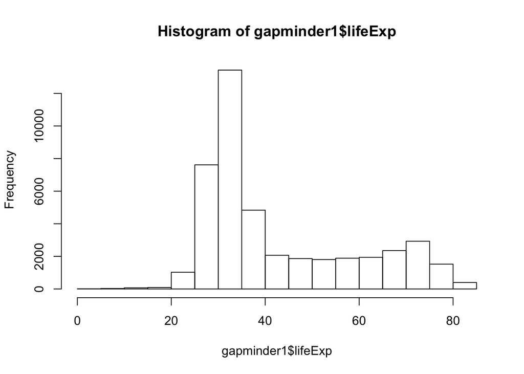

```r
#TODO 8.5: Draw histogram here
library(ggplot2)
hist(gapminder1$lifeExp)
```

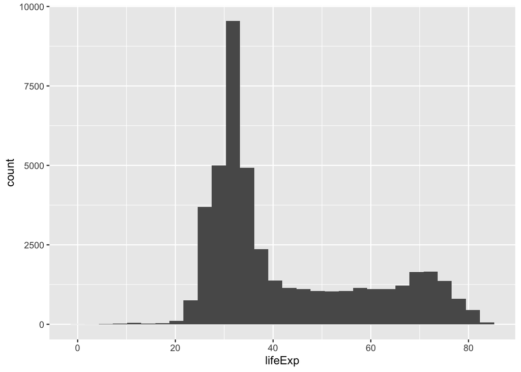

```r
## or
ggplot(gapminder1, aes(x = lifeExp)) + geom_histogram()
```

2. Draw side by side boxplots of life expectancy for the years 1900, 1910, 1920, 1930, 1940, 1950, 1960, 1970, 1980, and 1990. You’ll probably want to use `subset` in the `data` specification of `ggplot` to obtain only those 10 specific years. Also, try and use the `seq` function when you subset the data to avoid explicitly creating a vector of these dates.

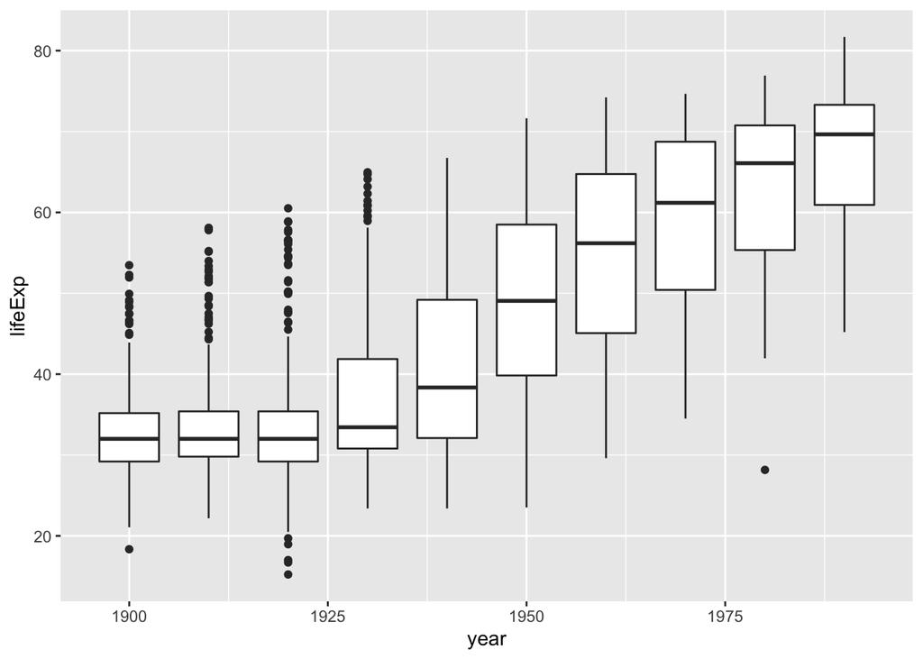

```r
#TODO 8.6: Draw side boxplots here
ggplot(subset(gapminder1, year %in% seq(1900, 1990, by = 10)), aes(x = year, y = lifeExp)) + geom_boxplot(aes(group = year))
```

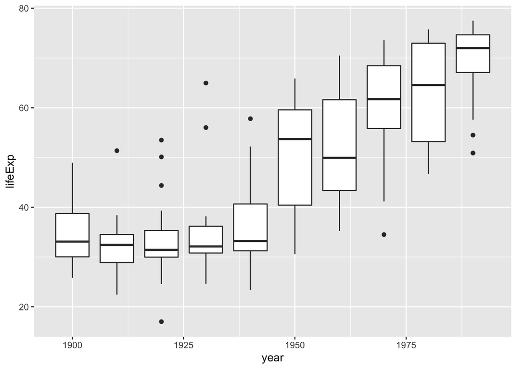

```r
## or
ggplot(gapminder1[gapminder1$year==seq(1900, 1990, by=10),], aes(x = year, y = lifeExp)) + geom_boxplot(aes(group = year))
```

3. Draw a line graph of the life expectancy against year for the United States.

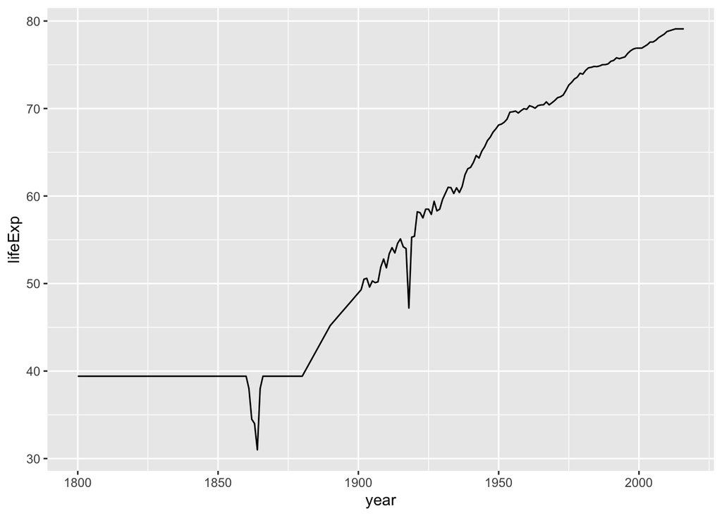

```r
##TODO 8.7: Draw line grph haere
ggplot(subset(gapminder1, country %in% c("United States")), aes(x = year, y = lifeExp)) + geom_line()
```

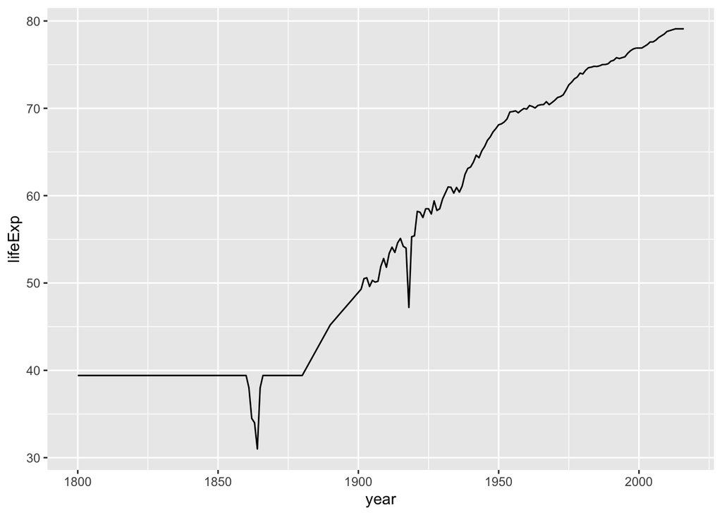

```r
## Or
ggplot(subset(gapminder1, country == "United States")) + geom_line(aes(x = year, y = lifeExp))
```

4. Draw (on the same set of axes) a line graph of life expectancy for the five most populous countries - China, India, United States, Indonesia, and Brazil - where each country’s line is a different color. (Any idea about why life expectancy dropped so much in many of these countries between 1911-1925?)

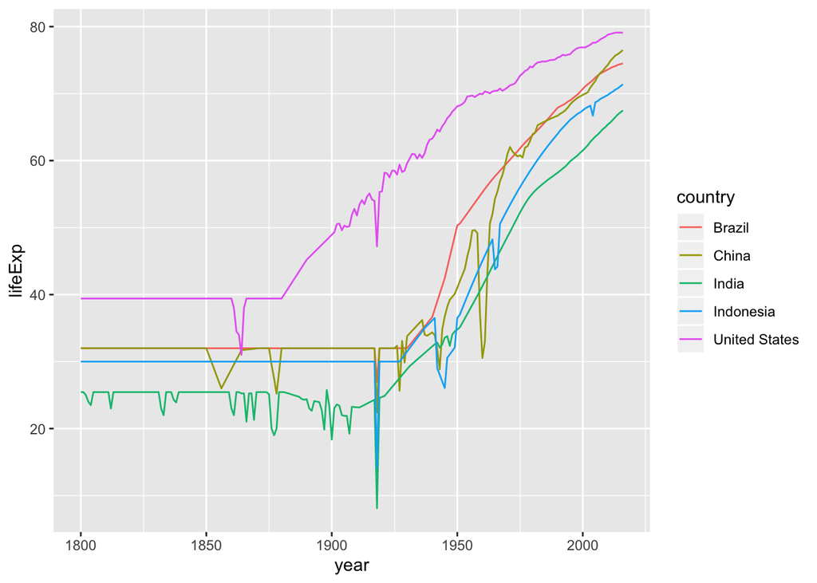

```r
##TODO 8.8: Draw line graph grouped by country here
populous_countries <- subset(gapminder1, country %in% c("China", "India", "United States", "Indonesia", "Brazil"))
ggplot(populous_countries, aes(x = year, y = lifeExp, group = country)) + geom_line(aes(color = country))
```

Congratulations! You’ve reached the end of Exercise 8.

###Questions?

If you have any lingering questions about the material in this document or in the corresponding chapter, put them here.

*None*

###Give us your feedback!

1. How do you feel you’re doing in this class?

*Learnt a lot from Help in R in this exercise.*

2. What could be done to improve your learning experience?

*The professors’ answrs on Piazza are very helpful. I think it would be helpful if add these reminders in the exercise.*